# Power analaysis in R

Gordana Popovic

7 April 2016

# What is power analysis, why is it important

You collect data to answer a question, usually detecting and effect (e.g. treatment effect). The power of your test is *the probability of detecting an effect (i.e.. get a p-value less than 0.05) with the experimental design you have and the effect size that you expect or consider meaningful*.

I’ll start by simulating a dataset which has an effect, and we’ll see if we can detect the effect. We’ll do a simple two sample t-test for illustration

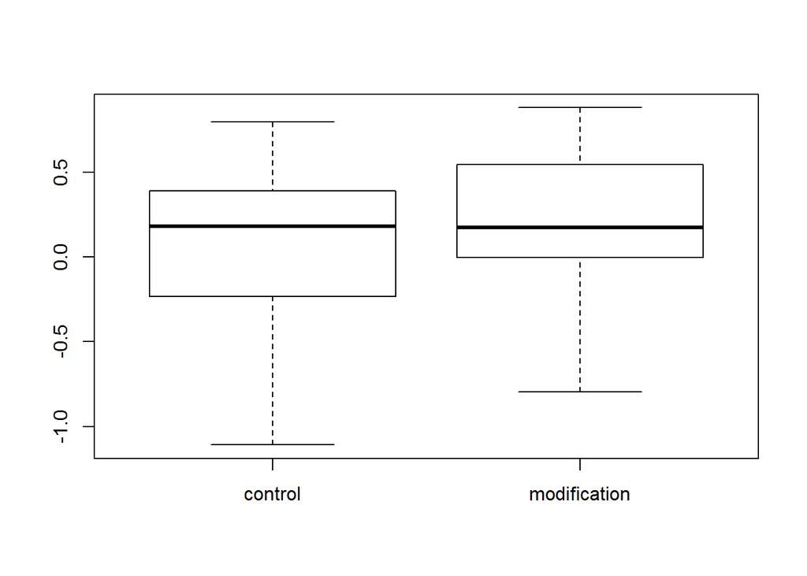

```r
set.seed(1)
N=20#sample size
trt.effect=0.2
sigma=0.5
mean.con=0 #mean of con gp
mean.trt=mean.con+trt.effect #mean of trt grp
control=rnorm(N,mean.con,sigma) #data for control
modification=rnorm(N,mean.trt,sigma) #data for modification
boxplot(cbind(control,modification))
```

```r
t.test(control,modification)
```

```
##
##  Welch Two Sample t-test
##
## data:  control and modification
## t = -0.71923, df = 37.917, p-value = 0.4764
## alternative hypothesis: true difference in means is not equal to 0
## 95 percent confidence interval:
##  -0.3872163  0.1842117
## sample estimates:
##  mean of x  mean of y
## 0.09526194 0.19676424
```

So we know there is a modification effect, with effect size 0.2, but the experiment was not able to detect it. Lets redo the same experiment with exactly the same setup.

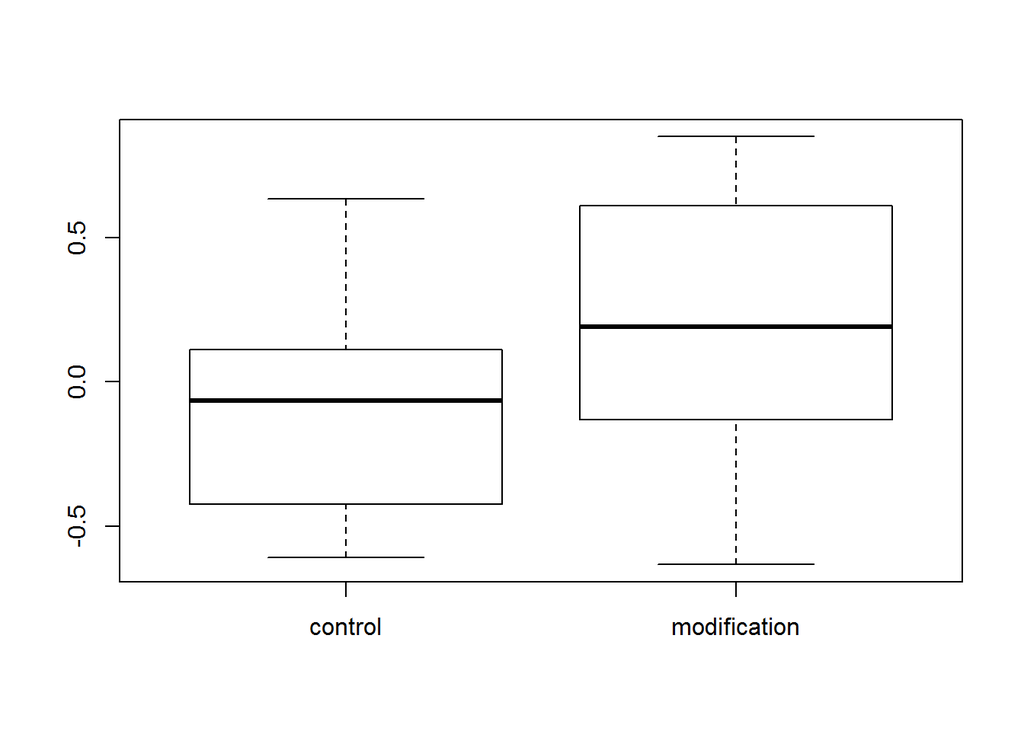

```r
#
set.seed(3)
N=20#sample size
trt.effect=0.2
sigma=0.5
mean.con=0 #mean of con gp
mean.trt=mean.con+trt.effect #mean of trt grp
control=rnorm(N,mean.con,sigma) #data for control
modification=rnorm(N,mean.trt,sigma) #data for modification
boxplot(cbind(control,modification))
```

```r
t.test(control,modification)
```

```
##
##  Welch Two Sample t-test
##
## data:  control and modification
## t = -2.3471, df = 37.416, p-value = 0.02432
## alternative hypothesis: true difference in means is not equal to 0
## 95 percent confidence interval:
##  -0.57817515 -0.04253493
## sample estimates:
##   mean of x   mean of y
## -0.08359522  0.22675982
```

This time we did detect an effect. This always happens, no matter what your experimental design, if an effect is present, you have some chance of detecting it, this is called power. So as not to waste time and money, we should only conduct experiments that have high power, i.e. high probability of detecting an effect if there is one. We can calculate the power of this experiment.

There’s various packages which do power analysis in R, ‘pwr’ does simple stuff up to lm and ‘simR’ does mixed models and glms.

## Simple power analysis with ‘pwr’

```r
library(pwr)
```

To do power calculations in *pwr* you leave one of the values as NULL and enter all the others, and it gives you the value for the one you left out. Here I leave out power, and it will calculate the power for the experimental design. Be careful; the d variable, which in the help file is called the effect size, is our treatment effect (difference between means) divided by the standard deviation.

```r
pwr.t.test(n = 20,d=trt.effect/sigma,sig.level = 0.05,power=NULL)
```

```
##
##      Two-sample t test power calculation
##
##               n = 20
##               d = 0.4
##       sig.level = 0.05
##           power = 0.2343494
##     alternative = two.sided
##
## NOTE: n is number in *each* group
```

Whoops, power is about 25%. So given the effect we expect, with this sample size we will only detect an effect 25% of the time, so it’s probably not worth doing this experiment. But we could increase the sample size to increase power. So what sample size will give us good power (80% power is the usual cutoff). We redo the calculation but now with N left blank and power = 0.8

```r
pwr.t.test(n = NULL,d=trt.effect/sigma,sig.level = 0.05,power=0.8)
```

```
##
##      Two-sample t test power calculation
##
##               n = 99.08032
##               d = 0.4
##       sig.level = 0.05
##           power = 0.8
##     alternative = two.sided
##
## NOTE: n is number in *each* group
```

So to have 80% power we need a sample size (for each group) of 100. We can also plot power for various sample sizes.

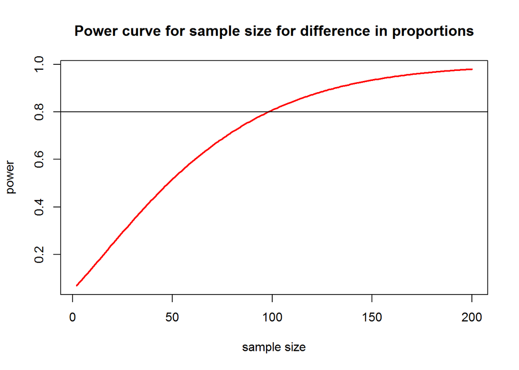

```r
nvals <- seq(2, 200, length.out=200)
powvals <- sapply(nvals, function (x) pwr.2p.test(h=trt.effect/sigma,n=x,sig.level = 0.05)$power)
plot(nvals, powvals, xlab="sample size", ylab="power",
main="Power curve for sample size for difference in proportions",
lwd=2, col="red", type="l")
abline(h=0.8)
```

The *pwr* package has a bunch of functions, but they all pretty much work the same way.

| Function | Description |
| --- | --- |
| pwr.2p.test | two proportions (equal n) |
| pwr.2p2n.test | two proportions (unequal n) |
| pwr.anova.test | balanced one way ANOVA |
| pwr.chisq.test | chi-square test |
| pwr.f2.test | general linear model |
| pwr.p.test | proportion (one sample) |
| pwr.r.test | correlation |
| pwr.t.test | t-tests (one sample, 2 sample, paired) |
| pwr.t2n.test | t-test (two samples with unequal n) |

It is generally a bit tricky to specify effect size, you can find a good guide for this package [here](http://www.statmethods.net/stats/power.html).

- Specifying effect size is not a statistical question, it’s an ecological question, what effect size is ecologically meaningful?

## Analysis with for linear and mixed models with ‘simr’

If you are conducting an experiment with random factors, and you need to do a mixed model, then your power analysis needs to reflect that. This is much harder to do than the above examples, and we will need to use simulation methods. The package ‘simr’ is designed to do this.

### Simple power analysis with pilot study data

#### Power analysis with a pilot study

We have conducted a pilot study, and now want to decide how we should allocate sampling for the full study. The study is looking for an effect of estuary modification on the abundance of a species. Lets assume we have the resources to do a maximum of 72 samples, and we want to maximize power for a test of the categorical variable ‘modification’. We have a pilot dataset ‘pilot’ which has a continuous fixed effect ‘temp’ a random effect for ‘site’ and a fixed effect ‘modification’, sites are nested in modification. The response variable is ‘abund’. We start by running the desired model on the pilot data.

```r
load("pilot.Rdata")
head(pilot)
```

```
##        temp modification site abund
## 1 0.3347758            1    a    18
## 2 0.9524330            1    a   244
## 3 0.6969579            1    a    91
## 4 0.7476786            1    b   121
## 5 0.1834330            1    b    15
## 6 0.5825847            1    b    67
```

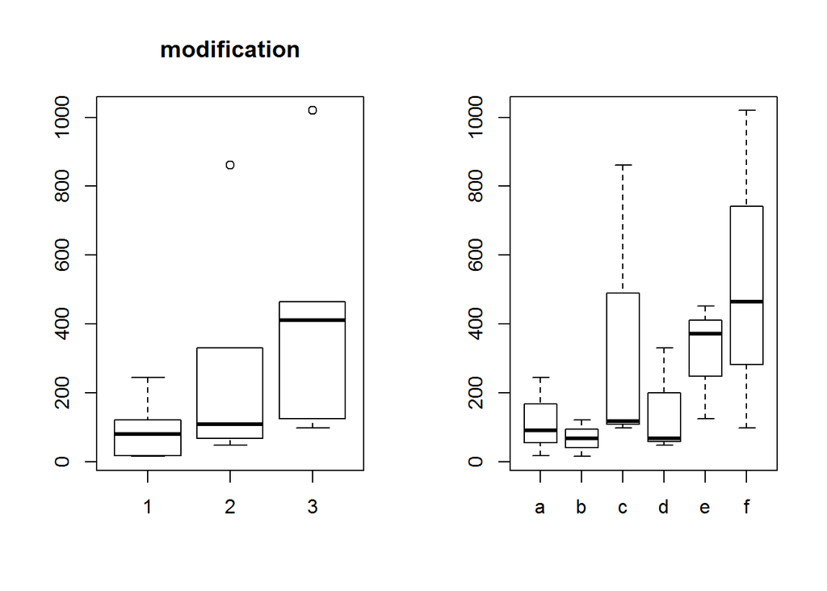

```r
pilot$modification<-factor(pilot$modification)
par(mfrow=c(1,2))
boxplot(abund~modification,data=pilot,main="modification")
boxplot(abund~site,data=pilot,meain="site")
```

```r
pilot.mod <- glmer(abund ~ temp + modification+(1|site), family="poisson", data=pilot)
summary(pilot.mod)
```

```
## Generalized linear mixed model fit by maximum likelihood (Laplace
##   Approximation) [glmerMod]
##  Family: poisson  ( log )
## Formula: abund ~ temp + modification + (1 | site)
##    Data: pilot
##
##      AIC      BIC   logLik deviance df.resid
##    153.3    157.7    -71.6    143.3       13
##
## Scaled residuals:
##     Min      1Q  Median      3Q     Max
## -1.2983 -0.4266  0.1293  0.4240  0.8410
##
## Random effects:
##  Groups Name        Variance Std.Dev.
##  site   (Intercept) 0.006274 0.07921
## Number of obs: 18, groups:  site, 6
##
## Fixed effects:
##               Estimate Std. Error z value Pr(>|z|)
## (Intercept)    1.69024    0.09851   17.16   <2e-16 ***
## temp           4.08409    0.08875   46.02   <2e-16 ***
## modification2  1.14103    0.09465   12.06   <2e-16 ***
## modification3  2.39503    0.09538   25.11   <2e-16 ***
## ---
## Signif. codes:  0 '***' 0.001 '**' 0.01 '*' 0.05 '.' 0.1 ' ' 1
##
## Correlation of Fixed Effects:
##             (Intr) temp   mdfct2
## temp        -0.692
## modificatn2 -0.558  0.023
## modificatn3 -0.696  0.226  0.565
```

We have data where sites are quite variable within modification There are two coefficients which specify effects of modification (as there are three modification categories). To do power analysis, we need to specify effect sizes for these which are ecologically meaningful. Keep in mind these are on the scale of the model, for a `poisson` model they are on the log scale (and multiplicative).

```r
fixef(pilot.mod)["modification2"] <- 0.1
fixef(pilot.mod)["modification3"] <- 0.2
```

We can now calculate the probability of an experiment with this sample size being able to detect a this modification effect, this is the ‘power’. I want to use a likelihood ratio test (i.e. use the anova() function) to test for an effect of modification, so i specify that with the ‘lr’ argument.

```r
powerSim(pilot.mod, fixed("modification", "lr"), nsim=500)
```

```
## Power for predictor 'modification', (95% confidence interval):
## 45.00% (40.58, 49.48)
##
## Test: Likelihood ratio
##
## Based on 500 simulations, (0 warnings, 0 errors)
## alpha = 0.05, nrow = 18
##
## Time elapsed: 0 h 1 m 32 s
```

```r
#this is a small number of sims for demonstration, the default of 1000 is more appropriate
```

#### Within vs along

We have several ways of adding observations to your data, you could sample more sites, but keep the number of samples per site the same, or you could keep the number of sites the same, and sample more within each site.

```r
xtabs(~modification+site,data=pilot)
```

```
##             site
## modification a b c d e f
##            1 3 3 0 0 0 0
##            2 0 0 3 3 0 0
##            3 0 0 0 0 3 3
```

There are currently 2 sites per modification with and 3 observations per site. Let’s try to increase the number of sites. We do this by adding data along site. With our budget of 72 observations and 3 observation per site we would have 24 sites.

```r
full1=extend(pilot.mod,along="site",n=24)
xtabs(~site,data=attributes(full1)$newData)
```

```
## site
##  1 10 11 12 13 14 15 16 17 18 19  2 20 21 22 23 24  3  4  5  6  7  8  9
##  3  3  3  3  3  3  3  3  3  3  3  3  3  3  3  3  3  3  3  3  3  3  3  3
```

```r
powerSim(full1, fixed("modification", "lr"), nsim=500)
```

```
## Power for predictor 'modification', (95% confidence interval):
## 90.60% (87.70, 93.01)
##
## Test: Likelihood ratio
##
## Based on 500 simulations, (0 warnings, 0 errors)
## alpha = 0.05, nrow = 72
##
## Time elapsed: 0 h 1 m 51 s
```

So we get about 90% power, sounds great. But what if instead we add more observations per site, would we do better or worse, for this we use the ‘within’ argument.

```r
full2=extend(pilot.mod,within="site",n=12)
xtabs(~site,data=attributes(full2)$newData)
```

```
## site
##  a  b  c  d  e  f
## 12 12 12 12 12 12
```

```r
powerSim(full2, fixed("modification", "lr"), nsim=500)
```

```
## Power for predictor 'modification', (95% confidence interval):
## 62.40% (57.99, 66.66)
##
## Test: Likelihood ratio
##
## Based on 500 simulations, (1 warning, 0 errors)
## alpha = 0.05, nrow = 72
##
## Time elapsed: 0 h 1 m 47 s
```

That only gives us about 65% power. So for this data, sampling design and question, it is better to add more sites. Of course you can also do combinations, maybe double the sites and double the observations per site.

```r
full3=extend(pilot.mod,within="site",n=6)
full3=extend(full3,along="site",n=12)

xtabs(~site,data=attributes(full3)$newData)
```

```
## site
##  1 10 11 12  2  3  4  5  6  7  8  9
##  6  6  6  6  6  6  6  6  6  6  6  6
```

```r
powerSim(full3, fixed("modification", "lr"), nsim=500)
```

```
## Power for predictor 'modification', (95% confidence interval):
## 74.80% (70.75, 78.55)
##
## Test: Likelihood ratio
##
## Based on 500 simulations, (0 warnings, 0 errors)
## alpha = 0.05, nrow = 72
##
## Time elapsed: 0 h 1 m 50 s
```

This gives 75% power, which is midway between the others. So in this case it is better to add more sites than more observation per site. This is by no means always true, and depended to a large extent on the variability within and between sites, your experimental design, your question.

### Some notes

- Power analysis give the probability of detecting a particular effect (of a particular strength), at a particular alpha level (usually 0.05) if this effect is present. If you are interested in multiple questions from the same data, to do power analysis you generally have to chose a question of primary interest
- You need to specify the level of the effect that you want to be able to detect, if you use the estimated level from a pilot study, this is called an “observed power” calculation, and is not a valid use of power analysis

### References

Some more examples from pilot studies

https://cran.r-project.org/web/packages/simr/vignettes/examples.html

Power analysis from scratch with no pilot study

https://cran.r-project.org/web/packages/simr/vignettes/fromscratch.html

More on specifying effect size

http://www.statmethods.net/stats/power.html